# Risk Factor Analysis

## Outcome Variable

**Outcome Variable:** wast_rec90d

## Predictor Variables

**Intervention Variable:** mhtcm

**Adjustment Set:**

unadjusted

## Stratifying Variables

The analysis was stratified on these variable(s):

- agecat
- studyid
- country

## Data Summary

| agecat | studyid | country | mhtcm | wast_rec90d | n_cell | n |
| --- | --- | --- | --- | --- | --- | --- |
| 0-24 months | COHORTS | GUATEMALA | >=155 cm | 0 | 25 | 373 |
| 0-24 months | COHORTS | GUATEMALA | >=155 cm | 1 | 25 | 373 |
| 0-24 months | COHORTS | GUATEMALA | <151 cm | 0 | 144 | 373 |
| 0-24 months | COHORTS | GUATEMALA | <151 cm | 1 | 112 | 373 |
| 0-24 months | COHORTS | GUATEMALA | [151-155) cm | 0 | 37 | 373 |
| 0-24 months | COHORTS | GUATEMALA | [151-155) cm | 1 | 30 | 373 |
| 0-24 months | COHORTS | INDIA | >=155 cm | 0 | 143 | 700 |
| 0-24 months | COHORTS | INDIA | >=155 cm | 1 | 66 | 700 |
| 0-24 months | COHORTS | INDIA | <151 cm | 0 | 240 | 700 |
| 0-24 months | COHORTS | INDIA | <151 cm | 1 | 69 | 700 |
| 0-24 months | COHORTS | INDIA | [151-155) cm | 0 | 138 | 700 |
| 0-24 months | COHORTS | INDIA | [151-155) cm | 1 | 44 | 700 |
| 0-24 months | COHORTS | PHILIPPINES | >=155 cm | 0 | 108 | 1689 |
| 0-24 months | COHORTS | PHILIPPINES | >=155 cm | 1 | 213 | 1689 |
| 0-24 months | COHORTS | PHILIPPINES | <151 cm | 0 | 380 | 1689 |
| 0-24 months | COHORTS | PHILIPPINES | <151 cm | 1 | 553 | 1689 |
| 0-24 months | COHORTS | PHILIPPINES | [151-155) cm | 0 | 176 | 1689 |
| 0-24 months | COHORTS | PHILIPPINES | [151-155) cm | 1 | 259 | 1689 |
| 0-24 months | Guatemala BSC | GUATEMALA | >=155 cm | 0 | 1 | 32 |
| 0-24 months | Guatemala BSC | GUATEMALA | >=155 cm | 1 | 2 | 32 |
| 0-24 months | Guatemala BSC | GUATEMALA | <151 cm | 0 | 10 | 32 |
| 0-24 months | Guatemala BSC | GUATEMALA | <151 cm | 1 | 10 | 32 |
| 0-24 months | Guatemala BSC | GUATEMALA | [151-155) cm | 0 | 7 | 32 |
| 0-24 months | Guatemala BSC | GUATEMALA | [151-155) cm | 1 | 2 | 32 |
| 0-24 months | iLiNS-Zinc | BURKINA FASO | >=155 cm | 0 | 661 | 794 |
| 0-24 months | iLiNS-Zinc | BURKINA FASO | >=155 cm | 1 | 31 | 794 |
| 0-24 months | iLiNS-Zinc | BURKINA FASO | <151 cm | 0 | 30 | 794 |
| 0-24 months | iLiNS-Zinc | BURKINA FASO | <151 cm | 1 | 1 | 794 |
| 0-24 months | iLiNS-Zinc | BURKINA FASO | [151-155) cm | 0 | 68 | 794 |
| 0-24 months | iLiNS-Zinc | BURKINA FASO | [151-155) cm | 1 | 3 | 794 |

[output cut: 378 more lines]

The following strata were considered:

- agecat: 0-24 months, studyid: COHORTS, country: GUATEMALA
- agecat: 0-24 months, studyid: COHORTS, country: INDIA
- agecat: 0-24 months, studyid: COHORTS, country: PHILIPPINES
- agecat: 0-24 months, studyid: Guatemala BSC, country: GUATEMALA
- agecat: 0-24 months, studyid: iLiNS-Zinc, country: BURKINA FASO
- agecat: 0-24 months, studyid: JiVitA-3, country: BANGLADESH
- agecat: 0-24 months, studyid: Keneba, country: GAMBIA
- agecat: 0-24 months, studyid: LCNI-5, country: MALAWI
- agecat: 0-24 months, studyid: MAL-ED, country: BANGLADESH
- agecat: 0-24 months, studyid: MAL-ED, country: BRAZIL
- agecat: 0-24 months, studyid: MAL-ED, country: INDIA
- agecat: 0-24 months, studyid: MAL-ED, country: NEPAL
- agecat: 0-24 months, studyid: MAL-ED, country: PERU
- agecat: 0-24 months, studyid: MAL-ED, country: SOUTH AFRICA
- agecat: 0-24 months, studyid: MAL-ED, country: TANZANIA, UNITED REPUBLIC OF
- agecat: 0-24 months, studyid: NIH-Birth, country: BANGLADESH
- agecat: 0-24 months, studyid: NIH-Crypto, country: BANGLADESH
- agecat: 0-24 months, studyid: PROBIT, country: BELARUS
- agecat: 0-24 months, studyid: PROVIDE, country: BANGLADESH
- agecat: 0-24 months, studyid: SAS-CompFeed, country: INDIA
- agecat: 0-24 months, studyid: SAS-FoodSuppl, country: INDIA
- agecat: 0-24 months, studyid: TanzaniaChild2, country: TANZANIA, UNITED REPUBLIC OF
- agecat: 0-24 months, studyid: ZVITAMBO, country: ZIMBABWE
- agecat: 0-6 months, studyid: COHORTS, country: GUATEMALA
- agecat: 0-6 months, studyid: COHORTS, country: INDIA
- agecat: 0-6 months, studyid: COHORTS, country: PHILIPPINES
- agecat: 0-6 months, studyid: Guatemala BSC, country: GUATEMALA
- agecat: 0-6 months, studyid: JiVitA-3, country: BANGLADESH
- agecat: 0-6 months, studyid: Keneba, country: GAMBIA
- agecat: 0-6 months, studyid: LCNI-5, country: MALAWI
- agecat: 0-6 months, studyid: MAL-ED, country: BANGLADESH
- agecat: 0-6 months, studyid: MAL-ED, country: BRAZIL
- agecat: 0-6 months, studyid: MAL-ED, country: INDIA
- agecat: 0-6 months, studyid: MAL-ED, country: NEPAL
- agecat: 0-6 months, studyid: MAL-ED, country: PERU
- agecat: 0-6 months, studyid: MAL-ED, country: SOUTH AFRICA
- agecat: 0-6 months, studyid: MAL-ED, country: TANZANIA, UNITED REPUBLIC OF
- agecat: 0-6 months, studyid: NIH-Birth, country: BANGLADESH
- agecat: 0-6 months, studyid: NIH-Crypto, country: BANGLADESH
- agecat: 0-6 months, studyid: PROBIT, country: BELARUS
- agecat: 0-6 months, studyid: PROVIDE, country: BANGLADESH
- agecat: 0-6 months, studyid: SAS-CompFeed, country: INDIA
- agecat: 0-6 months, studyid: SAS-FoodSuppl, country: INDIA
- agecat: 0-6 months, studyid: TanzaniaChild2, country: TANZANIA, UNITED REPUBLIC OF
- agecat: 0-6 months, studyid: ZVITAMBO, country: ZIMBABWE
- agecat: 6-24 months, studyid: COHORTS, country: GUATEMALA
- agecat: 6-24 months, studyid: COHORTS, country: INDIA
- agecat: 6-24 months, studyid: COHORTS, country: PHILIPPINES
- agecat: 6-24 months, studyid: Guatemala BSC, country: GUATEMALA
- agecat: 6-24 months, studyid: iLiNS-Zinc, country: BURKINA FASO
- agecat: 6-24 months, studyid: JiVitA-3, country: BANGLADESH
- agecat: 6-24 months, studyid: Keneba, country: GAMBIA
- agecat: 6-24 months, studyid: LCNI-5, country: MALAWI
- agecat: 6-24 months, studyid: MAL-ED, country: BANGLADESH
- agecat: 6-24 months, studyid: MAL-ED, country: BRAZIL
- agecat: 6-24 months, studyid: MAL-ED, country: INDIA
- agecat: 6-24 months, studyid: MAL-ED, country: NEPAL
- agecat: 6-24 months, studyid: MAL-ED, country: PERU
- agecat: 6-24 months, studyid: MAL-ED, country: SOUTH AFRICA
- agecat: 6-24 months, studyid: MAL-ED, country: TANZANIA, UNITED REPUBLIC OF
- agecat: 6-24 months, studyid: NIH-Birth, country: BANGLADESH
- agecat: 6-24 months, studyid: NIH-Crypto, country: BANGLADESH
- agecat: 6-24 months, studyid: PROBIT, country: BELARUS
- agecat: 6-24 months, studyid: PROVIDE, country: BANGLADESH
- agecat: 6-24 months, studyid: SAS-CompFeed, country: INDIA
- agecat: 6-24 months, studyid: SAS-FoodSuppl, country: INDIA
- agecat: 6-24 months, studyid: TanzaniaChild2, country: TANZANIA, UNITED REPUBLIC OF
- agecat: 6-24 months, studyid: ZVITAMBO, country: ZIMBABWE

### Dropped Strata

Some strata were dropped due to rare outcomes:

- agecat: 0-24 months, studyid: Guatemala BSC, country: GUATEMALA
- agecat: 0-24 months, studyid: iLiNS-Zinc, country: BURKINA FASO
- agecat: 0-24 months, studyid: LCNI-5, country: MALAWI
- agecat: 0-24 months, studyid: MAL-ED, country: BANGLADESH
- agecat: 0-24 months, studyid: MAL-ED, country: BRAZIL
- agecat: 0-24 months, studyid: MAL-ED, country: NEPAL
- agecat: 0-24 months, studyid: MAL-ED, country: PERU
- agecat: 0-24 months, studyid: MAL-ED, country: SOUTH AFRICA
- agecat: 0-24 months, studyid: MAL-ED, country: TANZANIA, UNITED REPUBLIC OF
- agecat: 0-24 months, studyid: PROBIT, country: BELARUS
- agecat: 0-24 months, studyid: SAS-FoodSuppl, country: INDIA
- agecat: 0-6 months, studyid: Guatemala BSC, country: GUATEMALA
- agecat: 0-6 months, studyid: LCNI-5, country: MALAWI
- agecat: 0-6 months, studyid: MAL-ED, country: BANGLADESH
- agecat: 0-6 months, studyid: MAL-ED, country: BRAZIL
- agecat: 0-6 months, studyid: MAL-ED, country: NEPAL
- agecat: 0-6 months, studyid: MAL-ED, country: PERU
- agecat: 0-6 months, studyid: MAL-ED, country: SOUTH AFRICA
- agecat: 0-6 months, studyid: MAL-ED, country: TANZANIA, UNITED REPUBLIC OF
- agecat: 0-6 months, studyid: NIH-Crypto, country: BANGLADESH
- agecat: 0-6 months, studyid: PROBIT, country: BELARUS
- agecat: 0-6 months, studyid: SAS-FoodSuppl, country: INDIA
- agecat: 6-24 months, studyid: COHORTS, country: GUATEMALA
- agecat: 6-24 months, studyid: COHORTS, country: INDIA
- agecat: 6-24 months, studyid: Guatemala BSC, country: GUATEMALA
- agecat: 6-24 months, studyid: iLiNS-Zinc, country: BURKINA FASO
- agecat: 6-24 months, studyid: JiVitA-3, country: BANGLADESH
- agecat: 6-24 months, studyid: LCNI-5, country: MALAWI
- agecat: 6-24 months, studyid: MAL-ED, country: BANGLADESH
- agecat: 6-24 months, studyid: MAL-ED, country: BRAZIL
- agecat: 6-24 months, studyid: MAL-ED, country: NEPAL
- agecat: 6-24 months, studyid: MAL-ED, country: PERU
- agecat: 6-24 months, studyid: MAL-ED, country: SOUTH AFRICA
- agecat: 6-24 months, studyid: MAL-ED, country: TANZANIA, UNITED REPUBLIC OF
- agecat: 6-24 months, studyid: NIH-Crypto, country: BANGLADESH
- agecat: 6-24 months, studyid: PROBIT, country: BELARUS
- agecat: 6-24 months, studyid: SAS-FoodSuppl, country: INDIA
- agecat: 6-24 months, studyid: ZVITAMBO, country: ZIMBABWE

## Methods Detail

We’re interested in the causal parameters $E[Y_a]$ for all values of $a \in \mathcal{A}$. These parameters represent the mean outcome if, possibly contrary to fact, we intervened to set all units to have $A=a$. Under the randomization and positivity assumptions, these are identified by the statistical parameters $\psi_a=E_W[E_{Y|A,W}(Y|A=a,W)]$. In addition, we’re interested in the mean of $Y$, $E[Y]$ under no intervention (the observed mean). We will estimate these parameters by using SuperLearner to fit the relevant likelihood factors – $E_{Y|A,W}(Y|A=a,W)$ and $p(A=a|W)$, and then updating our likelihood fit using a joint TMLE.

For unadjusted analyses ($W=\{\}$), initial likelihoods were estimated using Lrnr_glm to estimate the simple $E(Y|A)$ and Lrnr_mean to estimate $p(A)$. For adjusted analyses, a small library containing Lrnr_glmnet, Lrnr_xgboost, and Lrnr_mean was used.

Having estimated these parameters, we will then use the delta method to estimate relative risks and attributable risks relative to a prespecified baseline level of $A$.

# Results Detail

## Results Plots

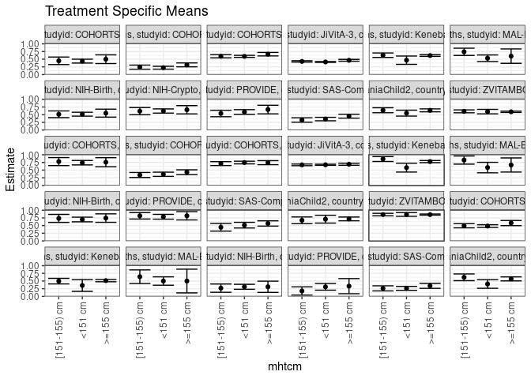

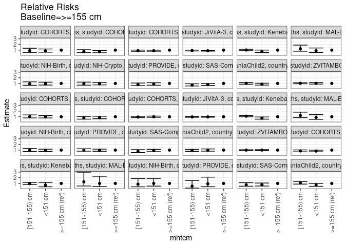

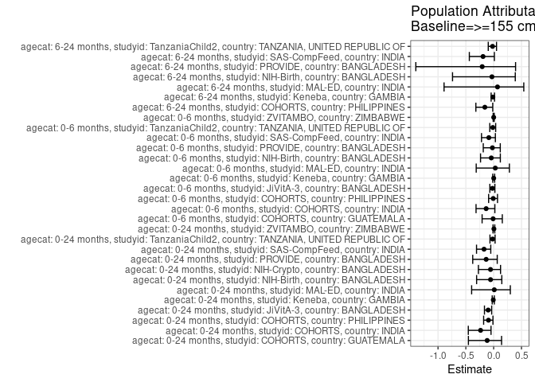

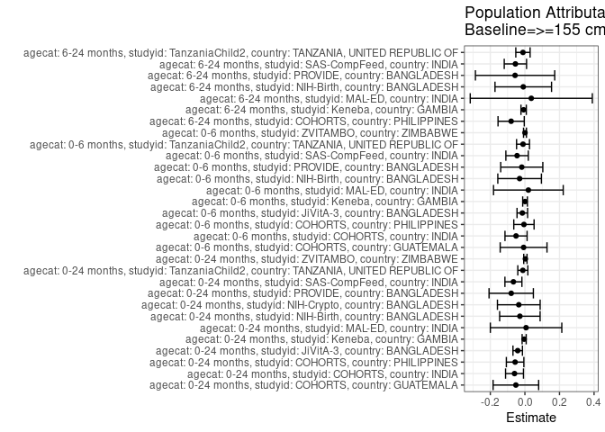

## Results Table

### Parameter: TSM

| agecat | studyid | country | intervention_level | baseline_level | estimate | ci_lower | ci_upper |
| --- | --- | --- | --- | --- | --- | --- | --- |
| 0-24 months | COHORTS | GUATEMALA | >=155 cm | NA | 0.5000000 | 0.3584406 | 0.6415594 |
| 0-24 months | COHORTS | GUATEMALA | <151 cm | NA | 0.4375000 | 0.3743588 | 0.5006412 |
| 0-24 months | COHORTS | GUATEMALA | [151-155) cm | NA | 0.4477612 | 0.3254443 | 0.5700781 |
| 0-24 months | COHORTS | INDIA | >=155 cm | NA | 0.3157895 | 0.2528309 | 0.3787480 |
| 0-24 months | COHORTS | INDIA | <151 cm | NA | 0.2233010 | 0.1766894 | 0.2699125 |
| 0-24 months | COHORTS | INDIA | [151-155) cm | NA | 0.2417582 | 0.1750359 | 0.3084806 |
| 0-24 months | COHORTS | PHILIPPINES | >=155 cm | NA | 0.6635514 | 0.6071777 | 0.7199251 |
| 0-24 months | COHORTS | PHILIPPINES | <151 cm | NA | 0.5927117 | 0.5605002 | 0.6249232 |
| 0-24 months | COHORTS | PHILIPPINES | [151-155) cm | NA | 0.5954023 | 0.5451884 | 0.6456162 |
| 0-24 months | JiVitA-3 | BANGLADESH | >=155 cm | NA | 0.4643180 | 0.4344793 | 0.4941566 |
| 0-24 months | JiVitA-3 | BANGLADESH | <151 cm | NA | 0.4103357 | 0.3960381 | 0.4246333 |
| 0-24 months | JiVitA-3 | BANGLADESH | [151-155) cm | NA | 0.4277457 | 0.4056693 | 0.4498220 |
| 0-24 months | Keneba | GAMBIA | >=155 cm | NA | 0.6195732 | 0.5919659 | 0.6471805 |
| 0-24 months | Keneba | GAMBIA | <151 cm | NA | 0.4677419 | 0.3327544 | 0.6027294 |
| 0-24 months | Keneba | GAMBIA | [151-155) cm | NA | 0.6308411 | 0.5588577 | 0.7028245 |
| 0-24 months | MAL-ED | INDIA | >=155 cm | NA | 0.6000000 | 0.3658974 | 0.8341026 |
| 0-24 months | MAL-ED | INDIA | <151 cm | NA | 0.5319149 | 0.4252678 | 0.6385620 |
| 0-24 months | MAL-ED | INDIA | [151-155) cm | NA | 0.7407407 | 0.6229295 | 0.8585519 |
| 0-24 months | NIH-Birth | BANGLADESH | >=155 cm | NA | 0.5492958 | 0.4196243 | 0.6789672 |
| 0-24 months | NIH-Birth | BANGLADESH | <151 cm | NA | 0.5151515 | 0.4516712 | 0.5786318 |
| 0-24 months | NIH-Birth | BANGLADESH | [151-155) cm | NA | 0.5116279 | 0.4024013 | 0.6208545 |
| 0-24 months | NIH-Crypto | BANGLADESH | >=155 cm | NA | 0.6600000 | 0.5249562 | 0.7950438 |
| 0-24 months | NIH-Crypto | BANGLADESH | <151 cm | NA | 0.6190476 | 0.5507022 | 0.6873930 |
| 0-24 months | NIH-Crypto | BANGLADESH | [151-155) cm | NA | 0.6142857 | 0.4966959 | 0.7318755 |
| 0-24 months | PROVIDE | BANGLADESH | >=155 cm | NA | 0.6666667 | 0.5273949 | 0.8059385 |
| 0-24 months | PROVIDE | BANGLADESH | <151 cm | NA | 0.5875706 | 0.5110627 | 0.6640785 |
| 0-24 months | PROVIDE | BANGLADESH | [151-155) cm | NA | 0.5384615 | 0.4330411 | 0.6438820 |
| 0-24 months | SAS-CompFeed | INDIA | >=155 cm | NA | 0.4509091 | 0.3874508 | 0.5143674 |
| 0-24 months | SAS-CompFeed | INDIA | <151 cm | NA | 0.3573883 | 0.3011074 | 0.4136692 |
| 0-24 months | SAS-CompFeed | INDIA | [151-155) cm | NA | 0.3258427 | 0.2539031 | 0.3977823 |

[output cut: 60 more lines]

### Parameter: E(Y)

| agecat | studyid | country | intervention_level | baseline_level | estimate | ci_lower | ci_upper |
| --- | --- | --- | --- | --- | --- | --- | --- |
| 0-24 months | COHORTS | GUATEMALA | NA | NA | 0.4477212 | 0.3954919 | 0.4999504 |
| 0-24 months | COHORTS | INDIA | NA | NA | 0.2557143 | 0.2227697 | 0.2886589 |
| 0-24 months | COHORTS | PHILIPPINES | NA | NA | 0.6068680 | 0.5823645 | 0.6313715 |
| 0-24 months | JiVitA-3 | BANGLADESH | NA | NA | 0.4226585 | 0.4115120 | 0.4338051 |
| 0-24 months | Keneba | GAMBIA | NA | NA | 0.6152905 | 0.5899139 | 0.6406671 |
| 0-24 months | MAL-ED | INDIA | NA | NA | 0.6067416 | 0.5268346 | 0.6866486 |
| 0-24 months | NIH-Birth | BANGLADESH | NA | NA | 0.5201900 | 0.4695846 | 0.5707955 |
| 0-24 months | NIH-Crypto | BANGLADESH | NA | NA | 0.6245955 | 0.5705077 | 0.6786833 |
| 0-24 months | PROVIDE | BANGLADESH | NA | NA | 0.5874587 | 0.5306185 | 0.6442990 |
| 0-24 months | SAS-CompFeed | INDIA | NA | NA | 0.3844086 | 0.3477135 | 0.4211037 |
| 0-24 months | TanzaniaChild2 | TANZANIA, UNITED REPUBLIC OF | NA | NA | 0.6283688 | 0.5905159 | 0.6662217 |
| 0-24 months | ZVITAMBO | ZIMBABWE | NA | NA | 0.5959970 | 0.5774555 | 0.6145386 |
| 0-6 months | COHORTS | GUATEMALA | NA | NA | 0.7500000 | 0.6917133 | 0.8082867 |
| 0-6 months | COHORTS | INDIA | NA | NA | 0.3800425 | 0.3361595 | 0.4239255 |
| 0-6 months | COHORTS | PHILIPPINES | NA | NA | 0.7367021 | 0.7051294 | 0.7682749 |
| 0-6 months | JiVitA-3 | BANGLADESH | NA | NA | 0.6758591 | 0.6624976 | 0.6892206 |
| 0-6 months | Keneba | GAMBIA | NA | NA | 0.7781155 | 0.7468871 | 0.8093439 |
| 0-6 months | MAL-ED | INDIA | NA | NA | 0.6867470 | 0.5837430 | 0.7897510 |
| 0-6 months | NIH-Birth | BANGLADESH | NA | NA | 0.7130045 | 0.6535890 | 0.7724200 |
| 0-6 months | PROVIDE | BANGLADESH | NA | NA | 0.8000000 | 0.7425836 | 0.8574164 |
| 0-6 months | SAS-CompFeed | INDIA | NA | NA | 0.5228758 | 0.4664267 | 0.5793250 |
| 0-6 months | TanzaniaChild2 | TANZANIA, UNITED REPUBLIC OF | NA | NA | 0.7053571 | 0.6558827 | 0.7548316 |
| 0-6 months | ZVITAMBO | ZIMBABWE | NA | NA | 0.8577803 | 0.8416785 | 0.8738820 |
| 6-24 months | COHORTS | PHILIPPINES | NA | NA | 0.5026681 | 0.4688378 | 0.5364984 |
| 6-24 months | Keneba | GAMBIA | NA | NA | 0.5056295 | 0.4721671 | 0.5390918 |
| 6-24 months | MAL-ED | INDIA | NA | NA | 0.5368421 | 0.4223932 | 0.6512910 |
| 6-24 months | NIH-Birth | BANGLADESH | NA | NA | 0.3030303 | 0.2377927 | 0.3682679 |
| 6-24 months | PROVIDE | BANGLADESH | NA | NA | 0.2764228 | 0.1950773 | 0.3577682 |
| 6-24 months | SAS-CompFeed | INDIA | NA | NA | 0.2876712 | 0.2441703 | 0.3311721 |
| 6-24 months | TanzaniaChild2 | TANZANIA, UNITED REPUBLIC OF | NA | NA | 0.5582656 | 0.5057575 | 0.6107737 |

### Parameter: RR

| agecat | studyid | country | intervention_level | baseline_level | estimate | ci_lower | ci_upper |
| --- | --- | --- | --- | --- | --- | --- | --- |
| 0-24 months | COHORTS | GUATEMALA | >=155 cm | >=155 cm | 1.0000000 | 1.0000000 | 1.0000000 |
| 0-24 months | COHORTS | GUATEMALA | <151 cm | >=155 cm | 0.8750000 | 0.6366850 | 1.2025176 |
| 0-24 months | COHORTS | GUATEMALA | [151-155) cm | >=155 cm | 0.8955224 | 0.6042766 | 1.3271411 |
| 0-24 months | COHORTS | INDIA | >=155 cm | >=155 cm | 1.0000000 | 1.0000000 | 1.0000000 |
| 0-24 months | COHORTS | INDIA | <151 cm | >=155 cm | 0.7071197 | 0.5298266 | 0.9437396 |
| 0-24 months | COHORTS | INDIA | [151-155) cm | >=155 cm | 0.7655678 | 0.5446634 | 1.0760665 |
| 0-24 months | COHORTS | PHILIPPINES | >=155 cm | >=155 cm | 1.0000000 | 1.0000000 | 1.0000000 |
| 0-24 months | COHORTS | PHILIPPINES | <151 cm | >=155 cm | 0.8932416 | 0.8075392 | 0.9880393 |
| 0-24 months | COHORTS | PHILIPPINES | [151-155) cm | >=155 cm | 0.8972964 | 0.7960561 | 1.0114122 |
| 0-24 months | JiVitA-3 | BANGLADESH | >=155 cm | >=155 cm | 1.0000000 | 1.0000000 | 1.0000000 |
| 0-24 months | JiVitA-3 | BANGLADESH | <151 cm | >=155 cm | 0.8837385 | 0.8214405 | 0.9507613 |
| 0-24 months | JiVitA-3 | BANGLADESH | [151-155) cm | >=155 cm | 0.9212343 | 0.8483488 | 1.0003818 |
| 0-24 months | Keneba | GAMBIA | >=155 cm | >=155 cm | 1.0000000 | 1.0000000 | 1.0000000 |
| 0-24 months | Keneba | GAMBIA | <151 cm | >=155 cm | 0.7549422 | 0.5637564 | 1.0109644 |
| 0-24 months | Keneba | GAMBIA | [151-155) cm | >=155 cm | 1.0181866 | 0.9007999 | 1.1508703 |
| 0-24 months | MAL-ED | INDIA | >=155 cm | >=155 cm | 1.0000000 | 1.0000000 | 1.0000000 |
| 0-24 months | MAL-ED | INDIA | <151 cm | >=155 cm | 0.8865248 | 0.5717136 | 1.3746854 |
| 0-24 months | MAL-ED | INDIA | [151-155) cm | >=155 cm | 1.2345679 | 0.8100813 | 1.8814875 |
| 0-24 months | NIH-Birth | BANGLADESH | >=155 cm | >=155 cm | 1.0000000 | 1.0000000 | 1.0000000 |
| 0-24 months | NIH-Birth | BANGLADESH | <151 cm | >=155 cm | 0.9378399 | 0.7185622 | 1.2240329 |
| 0-24 months | NIH-Birth | BANGLADESH | [151-155) cm | >=155 cm | 0.9314252 | 0.6773642 | 1.2807774 |
| 0-24 months | NIH-Crypto | BANGLADESH | >=155 cm | >=155 cm | 1.0000000 | 1.0000000 | 1.0000000 |
| 0-24 months | NIH-Crypto | BANGLADESH | <151 cm | >=155 cm | 0.9379509 | 0.7431366 | 1.1838361 |
| 0-24 months | NIH-Crypto | BANGLADESH | [151-155) cm | >=155 cm | 0.9307359 | 0.7031963 | 1.2319025 |
| 0-24 months | PROVIDE | BANGLADESH | >=155 cm | >=155 cm | 1.0000000 | 1.0000000 | 1.0000000 |
| 0-24 months | PROVIDE | BANGLADESH | <151 cm | >=155 cm | 0.8813559 | 0.6889589 | 1.1274813 |
| 0-24 months | PROVIDE | BANGLADESH | [151-155) cm | >=155 cm | 0.8076923 | 0.6065032 | 1.0756198 |
| 0-24 months | SAS-CompFeed | INDIA | >=155 cm | >=155 cm | 1.0000000 | 1.0000000 | 1.0000000 |
| 0-24 months | SAS-CompFeed | INDIA | <151 cm | >=155 cm | 0.7925951 | 0.6416779 | 0.9790067 |
| 0-24 months | SAS-CompFeed | INDIA | [151-155) cm | >=155 cm | 0.7226350 | 0.5561512 | 0.9389557 |

[output cut: 60 more lines]

### Parameter: PAR

| agecat | studyid | country | intervention_level | baseline_level | estimate | ci_lower | ci_upper |
| --- | --- | --- | --- | --- | --- | --- | --- |
| 0-24 months | COHORTS | GUATEMALA | >=155 cm | NA | -0.0522788 | -0.1840184 | 0.0794608 |
| 0-24 months | COHORTS | INDIA | >=155 cm | NA | -0.0600752 | -0.1119056 | -0.0082448 |
| 0-24 months | COHORTS | PHILIPPINES | >=155 cm | NA | -0.0566834 | -0.1073554 | -0.0060114 |
| 0-24 months | JiVitA-3 | BANGLADESH | >=155 cm | NA | -0.0416594 | -0.0691020 | -0.0142169 |
| 0-24 months | Keneba | GAMBIA | >=155 cm | NA | -0.0042827 | -0.0160681 | 0.0075027 |
| 0-24 months | MAL-ED | INDIA | >=155 cm | NA | 0.0067416 | -0.1999367 | 0.2134198 |
| 0-24 months | NIH-Birth | BANGLADESH | >=155 cm | NA | -0.0291058 | -0.1461229 | 0.0879114 |
| 0-24 months | NIH-Crypto | BANGLADESH | >=155 cm | NA | -0.0354045 | -0.1589419 | 0.0881329 |
| 0-24 months | PROVIDE | BANGLADESH | >=155 cm | NA | -0.0792079 | -0.2074206 | 0.0490048 |
| 0-24 months | SAS-CompFeed | INDIA | >=155 cm | NA | -0.0665005 | -0.1156391 | -0.0173619 |
| 0-24 months | TanzaniaChild2 | TANZANIA, UNITED REPUBLIC OF | >=155 cm | NA | -0.0120806 | -0.0411192 | 0.0169579 |
| 0-24 months | ZVITAMBO | ZIMBABWE | >=155 cm | NA | 0.0026731 | -0.0068206 | 0.0121668 |
| 0-6 months | COHORTS | GUATEMALA | >=155 cm | NA | -0.0075758 | -0.1429684 | 0.1278169 |
| 0-6 months | COHORTS | INDIA | >=155 cm | NA | -0.0513301 | -0.1152659 | 0.0126058 |
| 0-6 months | COHORTS | PHILIPPINES | >=155 cm | NA | -0.0056292 | -0.0643176 | 0.0530592 |
| 0-6 months | JiVitA-3 | BANGLADESH | >=155 cm | NA | -0.0150011 | -0.0455621 | 0.0155600 |
| 0-6 months | Keneba | GAMBIA | >=155 cm | NA | 0.0007432 | -0.0127862 | 0.0142727 |
| 0-6 months | MAL-ED | INDIA | >=155 cm | NA | 0.0200803 | -0.1814975 | 0.2216581 |
| 0-6 months | NIH-Birth | BANGLADESH | >=155 cm | NA | -0.0305853 | -0.1567104 | 0.0955399 |
| 0-6 months | PROVIDE | BANGLADESH | >=155 cm | NA | -0.0181818 | -0.1399756 | 0.1036120 |
| 0-6 months | SAS-CompFeed | INDIA | >=155 cm | NA | -0.0453060 | -0.1101364 | 0.0195244 |
| 0-6 months | TanzaniaChild2 | TANZANIA, UNITED REPUBLIC OF | >=155 cm | NA | -0.0109219 | -0.0482642 | 0.0264203 |
| 0-6 months | ZVITAMBO | ZIMBABWE | >=155 cm | NA | 0.0004336 | -0.0080133 | 0.0088805 |
| 6-24 months | COHORTS | PHILIPPINES | >=155 cm | NA | -0.0796104 | -0.1554859 | -0.0037349 |
| 6-24 months | Keneba | GAMBIA | >=155 cm | NA | -0.0073175 | -0.0227732 | 0.0081382 |
| 6-24 months | MAL-ED | INDIA | >=155 cm | NA | 0.0368421 | -0.3162378 | 0.3899220 |
| 6-24 months | NIH-Birth | BANGLADESH | >=155 cm | NA | -0.0094697 | -0.1730023 | 0.1540629 |
| 6-24 months | PROVIDE | BANGLADESH | >=155 cm | NA | -0.0569106 | -0.2862152 | 0.1723941 |
| 6-24 months | SAS-CompFeed | INDIA | >=155 cm | NA | -0.0549861 | -0.1195512 | 0.0095789 |
| 6-24 months | TanzaniaChild2 | TANZANIA, UNITED REPUBLIC OF | >=155 cm | NA | -0.0112996 | -0.0526484 | 0.0300491 |

### Parameter: PAF

| agecat | studyid | country | intervention_level | baseline_level | estimate | ci_lower | ci_upper |
| --- | --- | --- | --- | --- | --- | --- | --- |
| 0-24 months | COHORTS | GUATEMALA | >=155 cm | NA | -0.1167665 | -0.4538829 | 0.1421817 |
| 0-24 months | COHORTS | INDIA | >=155 cm | NA | -0.2349309 | -0.4558585 | -0.0475292 |
| 0-24 months | COHORTS | PHILIPPINES | >=155 cm | NA | -0.0934032 | -0.1802473 | -0.0129493 |
| 0-24 months | JiVitA-3 | BANGLADESH | >=155 cm | NA | -0.0985653 | -0.1654473 | -0.0355214 |
| 0-24 months | Keneba | GAMBIA | >=155 cm | NA | -0.0069604 | -0.0263103 | 0.0120246 |
| 0-24 months | MAL-ED | INDIA | >=155 cm | NA | 0.0111111 | -0.3959135 | 0.2994543 |
| 0-24 months | NIH-Birth | BANGLADESH | >=155 cm | NA | -0.0559522 | -0.3064224 | 0.1464973 |
| 0-24 months | NIH-Crypto | BANGLADESH | >=155 cm | NA | -0.0566839 | -0.2742450 | 0.1237313 |
| 0-24 months | PROVIDE | BANGLADESH | >=155 cm | NA | -0.1348315 | -0.3762480 | 0.0642367 |
| 0-24 months | SAS-CompFeed | INDIA | >=155 cm | NA | -0.1729943 | -0.3078807 | -0.0520192 |
| 0-24 months | TanzaniaChild2 | TANZANIA, UNITED REPUBLIC OF | >=155 cm | NA | -0.0192254 | -0.0665329 | 0.0259837 |
| 0-24 months | ZVITAMBO | ZIMBABWE | >=155 cm | NA | 0.0044851 | -0.0115755 | 0.0202907 |
| 0-6 months | COHORTS | GUATEMALA | >=155 cm | NA | -0.0101010 | -0.2077661 | 0.1552139 |
| 0-6 months | COHORTS | INDIA | >=155 cm | NA | -0.1350641 | -0.3167324 | 0.0215397 |
| 0-6 months | COHORTS | PHILIPPINES | >=155 cm | NA | -0.0076410 | -0.0905506 | 0.0689653 |
| 0-6 months | JiVitA-3 | BANGLADESH | >=155 cm | NA | -0.0221956 | -0.0684357 | 0.0220434 |
| 0-6 months | Keneba | GAMBIA | >=155 cm | NA | 0.0009552 | -0.0165860 | 0.0181937 |
| 0-6 months | MAL-ED | INDIA | >=155 cm | NA | 0.0292398 | -0.3137924 | 0.2827060 |
| 0-6 months | NIH-Birth | BANGLADESH | >=155 cm | NA | -0.0428963 | -0.2358326 | 0.1199191 |
| 0-6 months | PROVIDE | BANGLADESH | >=155 cm | NA | -0.0227273 | -0.1868832 | 0.1187245 |
| 0-6 months | SAS-CompFeed | INDIA | >=155 cm | NA | -0.0866477 | -0.2184394 | 0.0308887 |
| 0-6 months | TanzaniaChild2 | TANZANIA, UNITED REPUBLIC OF | >=155 cm | NA | -0.0154843 | -0.0698634 | 0.0361309 |
| 0-6 months | ZVITAMBO | ZIMBABWE | >=155 cm | NA | 0.0005055 | -0.0093907 | 0.0103046 |
| 6-24 months | COHORTS | PHILIPPINES | >=155 cm | NA | -0.1583757 | -0.3198566 | -0.0166515 |
| 6-24 months | Keneba | GAMBIA | >=155 cm | NA | -0.0144721 | -0.0455409 | 0.0156735 |
| 6-24 months | MAL-ED | INDIA | >=155 cm | NA | 0.0686275 | -0.8916940 | 0.5414402 |
| 6-24 months | NIH-Birth | BANGLADESH | >=155 cm | NA | -0.0312500 | -0.7392300 | 0.3885360 |
| 6-24 months | PROVIDE | BANGLADESH | >=155 cm | NA | -0.2058824 | -1.3990080 | 0.3938527 |
| 6-24 months | SAS-CompFeed | INDIA | >=155 cm | NA | -0.1911422 | -0.4372307 | 0.0128100 |
| 6-24 months | TanzaniaChild2 | TANZANIA, UNITED REPUBLIC OF | >=155 cm | NA | -0.0202406 | -0.0971904 | 0.0513124 |